# P8105 Homework 6

Yining Xiang

12/8/2020

## Problem 2

Load and clean the data for regression analysis (i.e. convert numeric to factor where appropriate, check for missing data, etc.).

```r
birthweight = read_csv("birthweight.csv") %>%
  mutate(babysex= factor(babysex, labels= c("female", "male")),
         frace= factor(frace, levels= c(1,2,3,4,8,9), labels= c("White", "Black", "Asian", "Puerto Rican", "Other", "Unknown")),
         malform= factor(malform, levels= c(0,1), labels= c("absent", "present")),
         mrace= factor(mrace, levels= c(1,2,3,4,8), labels= c("White", "Black", "Asian", "Puerto Rican", "Other"))) %>%
  na.omit(birthweight)
```

The model is structured as a possible prediction model of birthweight based on variables that could underly birthweight known prior to delivery. The model includes gestational age in weeks (gaweeks), presence of malformations (malform), mother’s age at delivery (momage), mother’s pre-pregnancy BMI (ppbmi) and mother’s weight gain during pregnancy (wtgain). Except the factor malformations, the rest four variables are pretty significant according to the summary.

```r
reg_proposed= lm(bwt~ gaweeks+ malform+ momage+ ppbmi+ wtgain, data= birthweight)

summary(reg_proposed)
```

```
##
## Call:
## lm(formula = bwt ~ gaweeks + malform + momage + ppbmi + wtgain,
##     data = birthweight)
##
## Residuals:
##      Min       1Q   Median       3Q      Max
## -1786.39  -290.48     1.77   293.96  1533.66
##
## Coefficients:
##                Estimate Std. Error t value Pr(>|t|)
## (Intercept)    -72.7604    99.4179  -0.732    0.464
## gaweeks         59.4021     2.2118  26.857  < 2e-16 ***
## malformpresent -45.8636   116.6135  -0.393    0.694
## momage          13.8723     1.7896   7.752 1.12e-14 ***
## ppbmi           15.9126     2.1690   7.337 2.60e-13 ***
## wtgain           9.9849     0.6395  15.614  < 2e-16 ***
## ---
## Signif. codes:  0 '***' 0.001 '**' 0.01 '*' 0.05 '.' 0.1 ' ' 1
##
## Residual standard error: 450.5 on 4336 degrees of freedom
## Multiple R-squared:  0.2271, Adjusted R-squared:  0.2262
## F-statistic: 254.8 on 5 and 4336 DF,  p-value: < 2.2e-16
```

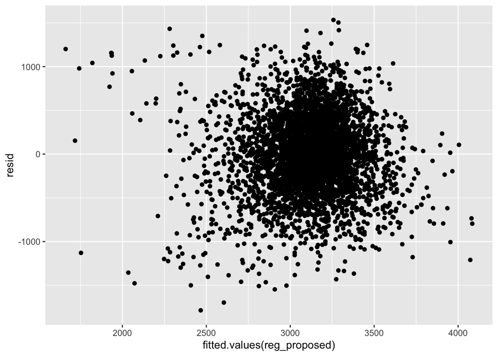

```r
modelr::add_residuals(birthweight, reg_proposed) %>%
  ggplot(aes(x= fitted.values(reg_proposed), y=resid))+
  geom_point()
```

Comparing the proposed one with another two models.

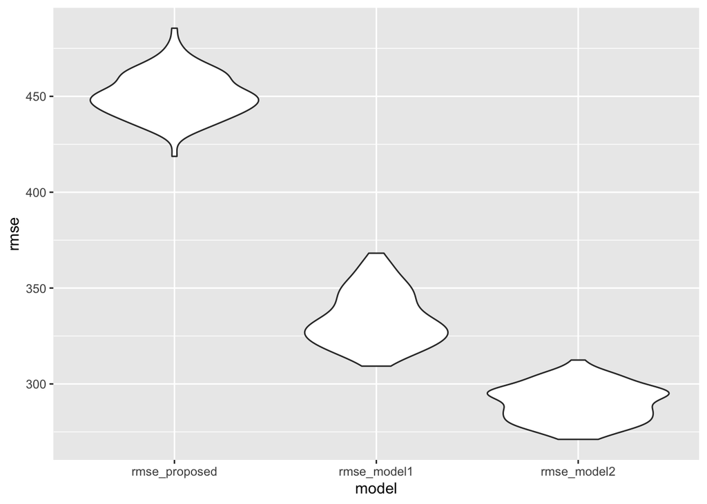

```r
reg_model1= lm(bwt~ blength+ gaweeks, data= birthweight)

reg_model2= lm(bwt~ bhead+ blength+ babysex+ bhead*blength+ bhead*babysex+ blength*babysex+ bhead*blength*babysex, data= birthweight)


cv_df =
  crossv_mc(birthweight, 100) %>%
  mutate(
    train = map(train, as_tibble),
    test = map(test, as_tibble))

cv_df =
  cv_df %>%
  mutate(
    reg_proposed  = map(.x= train, ~lm(bwt~ gaweeks+ malform+ momage+ ppbmi+ wtgain, data= .x)),
    reg_model1     = map(.x= train, ~lm(bwt~ blength+ gaweeks, data= .x)),
    reg_model2  = map(.x= train, ~lm(bwt~ bhead+ blength+ babysex+ bhead*blength+ bhead*babysex+ blength*babysex+ bhead*blength*babysex, data= .x))) %>%
  mutate(
    rmse_proposed = map2_dbl(.x= reg_proposed, .y= test, ~rmse(model = .x, data = .y)),
    rmse_model1    = map2_dbl(.x= reg_model1, .y= test, ~rmse(model = .x, data = .y)),
    rmse_model2 = map2_dbl(.x= reg_model2, .y= test, ~rmse(model = .x, data = .y)))

## plot
cv_df %>%
  select(starts_with("rmse")) %>%
  pivot_longer(
    everything(),
    names_to = "model",
    values_to = "rmse",
    names_prefix = "reg_") %>%
  mutate(model = fct_inorder(model)) %>%
  ggplot(aes(x = model, y = rmse)) + geom_violin()
```

Compare the models by rmse, we can see the model2 taking head circumference, length, sex, and all interactions (including the three-way interaction) between these, is the best model of the three.

## Problem 3

Part 1: plot the distribution of the estimates

```r
reg_weather= lm(tmax~ tmin, data= weather_df) %>% broom::tidy()

boot_sample = function(df) {
  sample_frac(df, replace = TRUE)
}

boot_straps =
  data_frame(
    strap_number = 1:5000,
    strap_sample = rerun(5000, boot_sample(weather_df))
  )
```

data wrangling

```r
boot_reg=
  boot_straps %>%
  mutate(
    models= map(.x= strap_sample, ~lm(tmax~tmin, data= .x)),
    r_squared= map(models, broom::glance)
  ) %>%
  select(strap_number, r_squared)%>%
  unnest(r_squared) %>%
  select(strap_number, r.squared)

boot_reg_beta=
  boot_straps %>%
  mutate(
    models= map(.x= strap_sample, ~lm(tmax~tmin, data= .x)),
    result= map(models, broom::tidy)
  ) %>%
  select(strap_number, result)

boot_reg_beta=
  boot_reg_beta %>%
  unnest(result) %>%
  select(strap_number, term, estimate) %>%
  pivot_wider(
    names_from = "term",
    values_from = "estimate"
    )

boot_1=
  merge(boot_reg, boot_reg_beta, by= "strap_number")
colnames(boot_1)= c("strap_number","r2","beta_0", "beta_1" )
boot_1=
  boot_1 %>%
  mutate(beta= log(beta_0*beta_1))
```

plotings

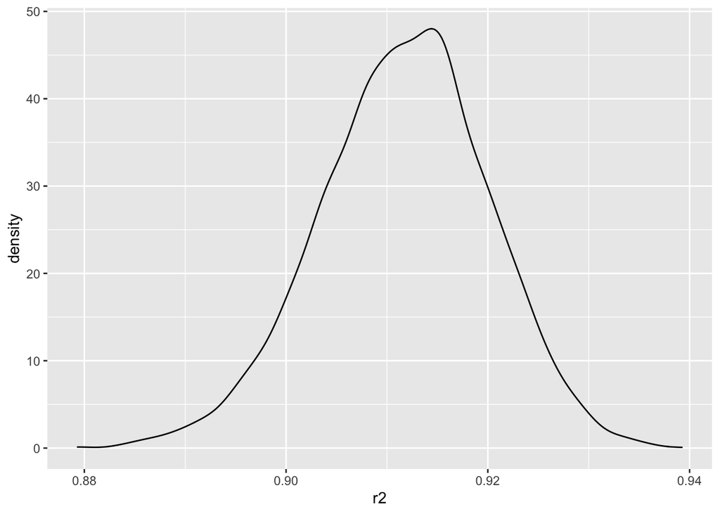

```r
boot_1 %>%
  ggplot(aes(x= r2))+
  geom_density()
```

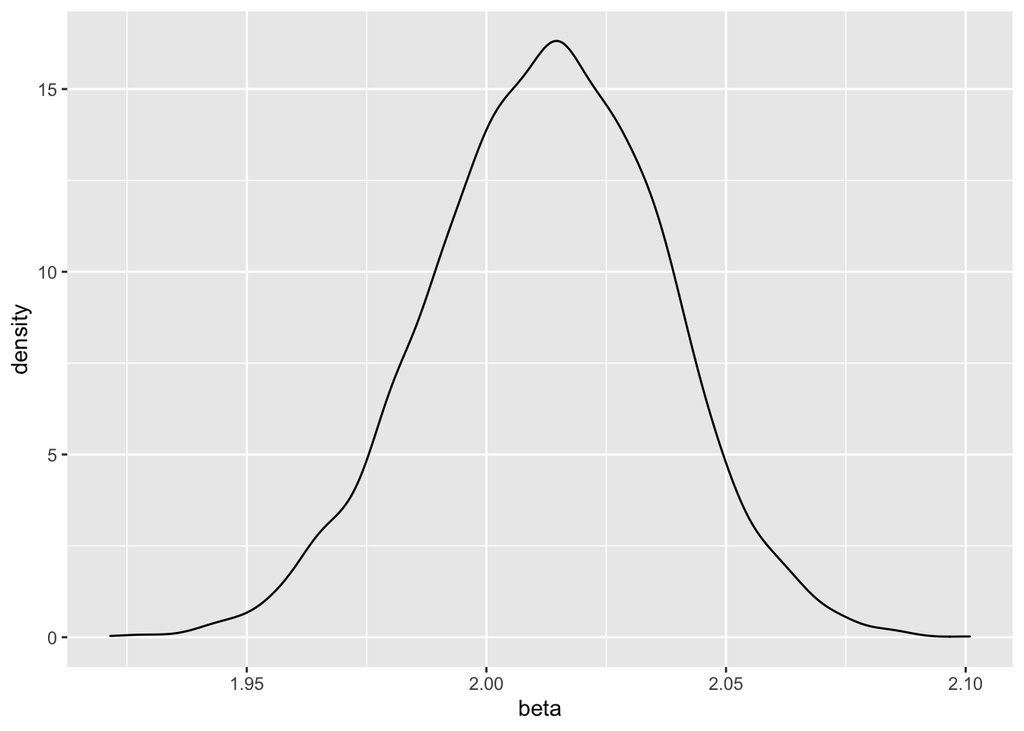

```r
boot_1%>%
  ggplot(aes(x= beta))+
  geom_density()
```

Part 2: generate the confidence interval

Using the 5000 bootstrap estimates, identify the 2.5% and 97.5% quantiles to provide a 95% confidence interval for r̂ 2 and log(β̂ 0∗β̂ 1 ).

```r
mean_r2= mean(boot_1$r2)
sd_r2= sd(boot_1$r2)

mean_beta= mean(boot_1$beta)
sd_beta= sd(boot_1$beta)

r2_ci= c(mean_r2-1.96*sd_r2/5000, mean_r2+1.96*sd_r2/5000)
beta_ci= c(mean_beta-1.96*sd_beta/5000, mean_beta+1.96*sd_beta/5000)

boot_1 %>%
  summarise(
     chopped_lowerbound_r2= quantile(r2,.025),
     chopped_upperbound_r2= quantile(r2,.975)
  )
```

```
##   chopped_lowerbound_r2 chopped_upperbound_r2
## 1             0.8944332              0.927498
```

```r
boot_1 %>%
  summarise(
     chopped_lowerbound_beta= quantile(beta,.025),
     chopped_upperbound_beta= quantile(beta,.975)
  )
```

```
##   chopped_lowerbound_beta chopped_upperbound_beta
## 1                 1.96388                2.059004
```